# Dimensionality_Reduction_PCA

kithsiri Jayakody

12/9/2020

loading the relavant files

```r
needed_packages <- c("psych",  "REdaS", "Hmisc", "corrplot", "ggcorrplot", "factoextra",  "nFactors")
# Extract not installed packages
not_installed <- needed_packages[!(needed_packages %in% installed.packages()[ , "Package"])]
# Install not installed packages
if(length(not_installed)) install.packages(not_installed, repos = "http://cran.us.r-project.org")
library(psych)
library(REdaS)
library(Hmisc)
library(corrplot)
library(ggcorrplot)
library(factoextra)#Used for principal component analysis to get a different view of eigenvalues
library(nFactors)
```

loading the file for the anaysis (this dataset included The results each student achieved on a 50-item IPIP Big-Five personality inventory has been included.). The IPIP items were administered using a 5-point, Likert-type scale ranging from 1 (disagree) to 5 (agree) as in the original instrument. This has resulted in 50 extra variables being added for each row. Each variable represents the student’s answer from 1 to 5 for each question or 0 if the question was not answered

```r
#load the dataset and remove every row when students didn't answer a question

setwd('D:/statistics')
# dataset is loading
df = read.csv('studentpIusepersonality.csv',stringsAsFactors = F)
```

getting only the required columns for the analysis

```r
# select only the required columns for the analysis . columns start with 55 to 197.
df1 = df[,c(55:64,78:87,98:107,188:197,198:207)]
# converting the character type into factorial variables and see the conversion
View(df1)
```

```r
#remove any row which has the value = 0 . it means it is not answered.
df2 <- na.omit(df1)
```

check corelation matrix ( it will shows a 50 * 50 matrix)

```r
#create a correlation matrix (these are just some methods)
raqMatrix<-cor(df2)
round(raqMatrix, 2)
```

```
##        A1    A2    A3    A4    A5    A6    A7    A8    A9   A10    C1    C2
## A1   1.00  0.39  0.56  0.43  0.42  0.45  0.31 -0.18 -0.30 -0.16 -0.02  0.10
## A2   0.39  1.00  0.43  0.40  0.44  0.51  0.37 -0.17 -0.27 -0.08  0.00  0.19
## A3   0.56  0.43  1.00  0.33  0.30  0.44  0.41 -0.11 -0.28 -0.16 -0.06  0.08
## A4   0.43  0.40  0.33  1.00  0.28  0.34  0.25 -0.24 -0.39 -0.18  0.06  0.13
## A5   0.42  0.44  0.30  0.28  1.00  0.46  0.26 -0.21 -0.37 -0.15  0.15  0.16
## A6   0.45  0.51  0.44  0.34  0.46  1.00  0.27 -0.09 -0.27 -0.07  0.15  0.33
## A7   0.31  0.37  0.41  0.25  0.26  0.27  1.00 -0.28 -0.28 -0.26  0.01  0.00
## A8  -0.18 -0.17 -0.11 -0.24 -0.21 -0.09 -0.28  1.00  0.30  0.24  0.03  0.14
## A9  -0.30 -0.27 -0.28 -0.39 -0.37 -0.27 -0.28  0.30  1.00  0.30 -0.03  0.00
## A10 -0.16 -0.08 -0.16 -0.18 -0.15 -0.07 -0.26  0.24  0.30  1.00 -0.01  0.08
## C1  -0.02  0.00 -0.06  0.06  0.15  0.15  0.01  0.03 -0.03 -0.01  1.00  0.31
## C2   0.10  0.19  0.08  0.13  0.16  0.33  0.00  0.14  0.00  0.08  0.31  1.00
## C3   0.24  0.20  0.13  0.11  0.17  0.36 -0.04  0.10 -0.03 -0.02  0.22  0.49
## C4   0.04  0.18  0.03  0.10  0.14  0.29  0.06  0.18  0.01  0.05  0.24  0.44
## C5   0.02  0.04 -0.01  0.08  0.19  0.19  0.02  0.01 -0.13 -0.01  0.32  0.31
## C6   0.13  0.12  0.10  0.10 -0.10 -0.10 -0.03 -0.03  0.13  0.05 -0.33 -0.24
## C7   0.05  0.03  0.18  0.06 -0.16 -0.14 -0.04  0.00  0.15  0.07 -0.45 -0.43
## C8  -0.04 -0.05  0.08  0.01 -0.13 -0.18  0.01 -0.06  0.05  0.06 -0.30 -0.63
## C9  -0.01  0.02  0.07 -0.09 -0.09 -0.15 -0.02  0.05  0.15  0.14 -0.28 -0.39
## C10 -0.04 -0.01  0.12  0.02 -0.13 -0.15  0.02 -0.01  0.11  0.10 -0.26 -0.40
## E1   0.22  0.36  0.16  0.18  0.38  0.29  0.20 -0.06 -0.16 -0.03  0.17  0.27
## E2   0.12  0.37  0.04  0.15  0.21  0.20  0.15  0.02 -0.10  0.09  0.06  0.17
## E3   0.28  0.36  0.21  0.26  0.29  0.23  0.15  0.03 -0.14  0.08  0.10  0.10
## E4   0.13  0.35  0.09  0.18  0.24  0.22  0.19 -0.03 -0.12  0.12  0.03  0.14
## E5   0.39  0.43  0.28  0.34  0.41  0.43  0.19 -0.06 -0.15 -0.05  0.06  0.21
## E6   0.15  0.29  0.17  0.10  0.18  0.08  0.12 -0.04  0.01  0.07 -0.09  0.06
## E7  -0.08 -0.13 -0.10 -0.09 -0.21 -0.08 -0.17  0.14  0.24  0.17 -0.01  0.01
## E8  -0.03 -0.13  0.05 -0.09 -0.25 -0.05 -0.11  0.08  0.22  0.07 -0.11 -0.05
## E9  -0.11 -0.08 -0.07 -0.15 -0.15 -0.14 -0.09  0.13  0.15  0.15 -0.06 -0.10
## E10  0.02  0.01  0.05 -0.07 -0.10  0.10 -0.06  0.04  0.10 -0.01  0.09  0.12
## N1  -0.12 -0.21 -0.05 -0.14 -0.25 -0.22 -0.22  0.17  0.38  0.11 -0.15 -0.18
## N2   0.02 -0.05  0.08 -0.08 -0.11 -0.03 -0.20  0.20  0.26  0.09 -0.09  0.07
## N3   0.02 -0.08  0.07 -0.04 -0.13 -0.04 -0.14  0.19  0.25  0.08 -0.06  0.09
## N4  -0.03 -0.08  0.01 -0.10 -0.17  0.00 -0.18  0.15  0.30  0.07 -0.10  0.05
## N5   0.03 -0.08  0.02 -0.05 -0.09  0.04 -0.21  0.17  0.14  0.08  0.02  0.09
## N6   0.03 -0.04  0.11 -0.05 -0.16  0.02 -0.13  0.29  0.20  0.01 -0.04  0.16
## N7  -0.12 -0.21 -0.06 -0.17 -0.21 -0.18 -0.15  0.14  0.26  0.06 -0.08 -0.01
## N8   0.22  0.45  0.26  0.21  0.23  0.36  0.28 -0.03 -0.18  0.07  0.09  0.21
## N9   0.21  0.31  0.15  0.19  0.23  0.31  0.26 -0.10 -0.18 -0.07  0.18  0.23
```

[output cut: 200 more lines]

```
## N6   0.00  0.05
## N7  -0.01  0.01
## N8   0.07  0.02
## N9  -0.06 -0.10
## N10  0.07 -0.02
## O1  -0.01  0.10
## O2  -0.37 -0.41
## O3  -0.20 -0.06
## O4  -0.22 -0.13
## O5  -0.16 -0.11
## O6   0.33  0.26
## O7   0.40  0.29
## O8   0.60  0.47
## O9   1.00  0.42
## O10  0.42  1.00
```

```r
Hmisc::rcorr(as.matrix(df2))
```

```
##        A1    A2    A3    A4    A5    A6    A7    A8    A9   A10    C1    C2
## A1   1.00  0.39  0.56  0.43  0.42  0.45  0.31 -0.18 -0.30 -0.16 -0.02  0.10
## A2   0.39  1.00  0.43  0.40  0.44  0.51  0.37 -0.17 -0.27 -0.08  0.00  0.19
## A3   0.56  0.43  1.00  0.33  0.30  0.44  0.41 -0.11 -0.28 -0.16 -0.06  0.08
## A4   0.43  0.40  0.33  1.00  0.28  0.34  0.25 -0.24 -0.39 -0.18  0.06  0.13
## A5   0.42  0.44  0.30  0.28  1.00  0.46  0.26 -0.21 -0.37 -0.15  0.15  0.16
## A6   0.45  0.51  0.44  0.34  0.46  1.00  0.27 -0.09 -0.27 -0.07  0.15  0.33
## A7   0.31  0.37  0.41  0.25  0.26  0.27  1.00 -0.28 -0.28 -0.26  0.01  0.00
## A8  -0.18 -0.17 -0.11 -0.24 -0.21 -0.09 -0.28  1.00  0.30  0.24  0.03  0.14
## A9  -0.30 -0.27 -0.28 -0.39 -0.37 -0.27 -0.28  0.30  1.00  0.30 -0.03  0.00
## A10 -0.16 -0.08 -0.16 -0.18 -0.15 -0.07 -0.26  0.24  0.30  1.00 -0.01  0.08
## C1  -0.02  0.00 -0.06  0.06  0.15  0.15  0.01  0.03 -0.03 -0.01  1.00  0.31
## C2   0.10  0.19  0.08  0.13  0.16  0.33  0.00  0.14  0.00  0.08  0.31  1.00
## C3   0.24  0.20  0.13  0.11  0.17  0.36 -0.04  0.10 -0.03 -0.02  0.22  0.49
## C4   0.04  0.18  0.03  0.10  0.14  0.29  0.06  0.18  0.01  0.05  0.24  0.44
## C5   0.02  0.04 -0.01  0.08  0.19  0.19  0.02  0.01 -0.13 -0.01  0.32  0.31
## C6   0.13  0.12  0.10  0.10 -0.10 -0.10 -0.03 -0.03  0.13  0.05 -0.33 -0.24
## C7   0.05  0.03  0.18  0.06 -0.16 -0.14 -0.04  0.00  0.15  0.07 -0.45 -0.43
## C8  -0.04 -0.05  0.08  0.01 -0.13 -0.18  0.01 -0.06  0.05  0.06 -0.30 -0.63
## C9  -0.01  0.02  0.07 -0.09 -0.09 -0.15 -0.02  0.05  0.15  0.14 -0.28 -0.39
## C10 -0.04 -0.01  0.12  0.02 -0.13 -0.15  0.02 -0.01  0.11  0.10 -0.26 -0.40
## E1   0.22  0.36  0.16  0.18  0.38  0.29  0.20 -0.06 -0.16 -0.03  0.17  0.27
## E2   0.12  0.37  0.04  0.15  0.21  0.20  0.15  0.02 -0.10  0.09  0.06  0.17
## E3   0.28  0.36  0.21  0.26  0.29  0.23  0.15  0.03 -0.14  0.08  0.10  0.10
## E4   0.13  0.35  0.09  0.18  0.24  0.22  0.19 -0.03 -0.12  0.12  0.03  0.14
## E5   0.39  0.43  0.28  0.34  0.41  0.43  0.19 -0.06 -0.15 -0.05  0.06  0.21
## E6   0.15  0.29  0.17  0.10  0.18  0.08  0.12 -0.04  0.01  0.07 -0.09  0.06
## E7  -0.08 -0.13 -0.10 -0.09 -0.21 -0.08 -0.17  0.14  0.24  0.17 -0.01  0.01
## E8  -0.03 -0.13  0.05 -0.09 -0.25 -0.05 -0.11  0.08  0.22  0.07 -0.11 -0.05
## E9  -0.11 -0.08 -0.07 -0.15 -0.15 -0.14 -0.09  0.13  0.15  0.15 -0.06 -0.10
## E10  0.02  0.01  0.05 -0.07 -0.10  0.10 -0.06  0.04  0.10 -0.01  0.09  0.12
## N1  -0.12 -0.21 -0.05 -0.14 -0.25 -0.22 -0.22  0.17  0.38  0.11 -0.15 -0.18
## N2   0.02 -0.05  0.08 -0.08 -0.11 -0.03 -0.20  0.20  0.26  0.09 -0.09  0.07
## N3   0.02 -0.08  0.07 -0.04 -0.13 -0.04 -0.14  0.19  0.25  0.08 -0.06  0.09
## N4  -0.03 -0.08  0.01 -0.10 -0.17  0.00 -0.18  0.15  0.30  0.07 -0.10  0.05
## N5   0.03 -0.08  0.02 -0.05 -0.09  0.04 -0.21  0.17  0.14  0.08  0.02  0.09
## N6   0.03 -0.04  0.11 -0.05 -0.16  0.02 -0.13  0.29  0.20  0.01 -0.04  0.16
## N7  -0.12 -0.21 -0.06 -0.17 -0.21 -0.18 -0.15  0.14  0.26  0.06 -0.08 -0.01
## N8   0.22  0.45  0.26  0.21  0.23  0.36  0.28 -0.03 -0.18  0.07  0.09  0.21
## N9   0.21  0.31  0.15  0.19  0.23  0.31  0.26 -0.10 -0.18 -0.07  0.18  0.23
```

[output cut: 460 more lines]

```
## N6  0.1536 0.3029 0.0045 0.0000 0.0000 0.2939 0.3436 0.5737 0.9381 0.3345
## N7  0.2568 0.1771 0.0142 0.0556 0.1043 0.6494 0.1840 0.5635 0.7748 0.7842
## N8  0.0014 0.0003 0.0000 0.0395 0.0408 0.4204 0.5489 0.7592 0.1882 0.6811
## N9  0.3316 0.0000 0.0027 0.5502 0.0829 0.0675 0.5138 0.2756 0.2102 0.0622
## N10 0.3417 0.3410 0.7063 0.1682 0.0392 0.9056 0.4502 0.9114 0.1633 0.7054
## O1         0.1520 0.0000 0.0000 0.0000 0.4146 0.0047 0.5479 0.8552 0.0594
## O2  0.1520        0.0000 0.0000 0.0000 0.0000 0.0000 0.0000 0.0000 0.0000
## O3  0.0000 0.0000        0.0000 0.0000 0.0000 0.0000 0.0000 0.0000 0.2722
## O4  0.0000 0.0000 0.0000        0.0000 0.0005 0.0000 0.0000 0.0000 0.0097
## O5  0.0000 0.0000 0.0000 0.0000        0.0022 0.0077 0.0004 0.0021 0.0347
## O6  0.4146 0.0000 0.0000 0.0005 0.0022        0.0000 0.0000 0.0000 0.0000
## O7  0.0047 0.0000 0.0000 0.0000 0.0077 0.0000        0.0000 0.0000 0.0000
## O8  0.5479 0.0000 0.0000 0.0000 0.0004 0.0000 0.0000        0.0000 0.0000
## O9  0.8552 0.0000 0.0000 0.0000 0.0021 0.0000 0.0000 0.0000        0.0000
## O10 0.0594 0.0000 0.2722 0.0097 0.0347 0.0000 0.0000 0.0000 0.0000
```

as the out put there is not clear, here with I’m creating a ggplot matrix for clear visualization

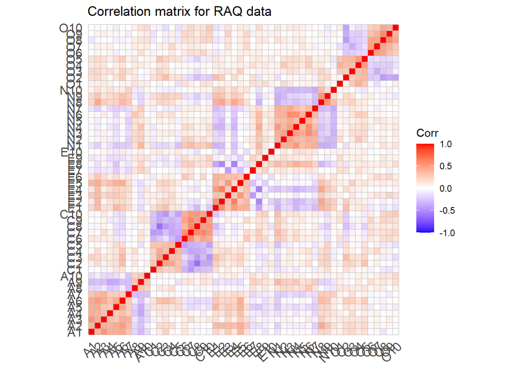

```r
#Using ggcorrplot. Note these are examples you need to choose a style for yourself, you do not need to create multiple correlation matrices
p.mat <- ggcorrplot::cor_pmat(df2)
ggcorrplot::ggcorrplot(raqMatrix, title = "Correlation matrix for RAQ data")
```

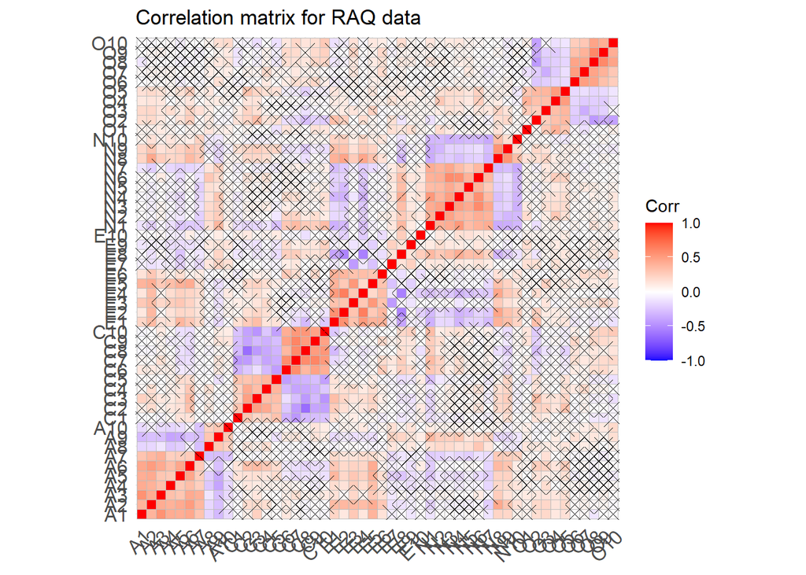

```r
#Showing Xs for non-significant correlations
ggcorrplot::ggcorrplot(raqMatrix, title = "Correlation matrix for RAQ data", p.mat = p.mat, sig.level = .05)
```

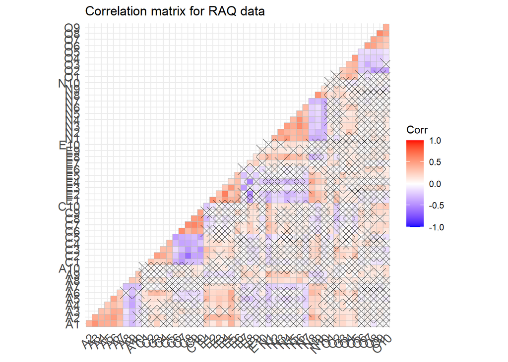

```r
#Showing lower diagonal
ggcorrplot::ggcorrplot(raqMatrix, title = "Correlation matrix for RAQ data", p.mat = p.mat, sig.level = .05, type="lower")
```

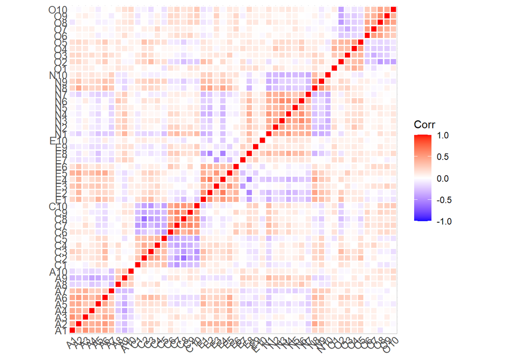

```r
#Overlay plot with a white grid to space things out.
#t1.cex is the text size, pch is controlling what is shown for non-significant correlations
ggcorrplot(raqMatrix, sig.level=0.05, lab_size = 4.5, p.mat = NULL,
           insig = c("pch", "blank"), pch = 1, pch.col = "black", pch.cex =1,
           tl.cex = 10) +
  theme(axis.text.x = element_text(margin=margin(-2,0,0,0)),
        axis.text.y = element_text(margin=margin(0,-2,0,0)),
        panel.grid.minor = element_line(size=10)) +
  geom_tile(fill="white") +
  geom_tile(height=0.8, width=0.8)
```

[figure not shown]

```r
#Showing the co-coefficients (this will be messy given the number of variables)
ggcorrplot::ggcorrplot(raqMatrix, lab=TRUE, title = "Correlation matrix for RAQ data",  type="lower")
```

using the corelation plots

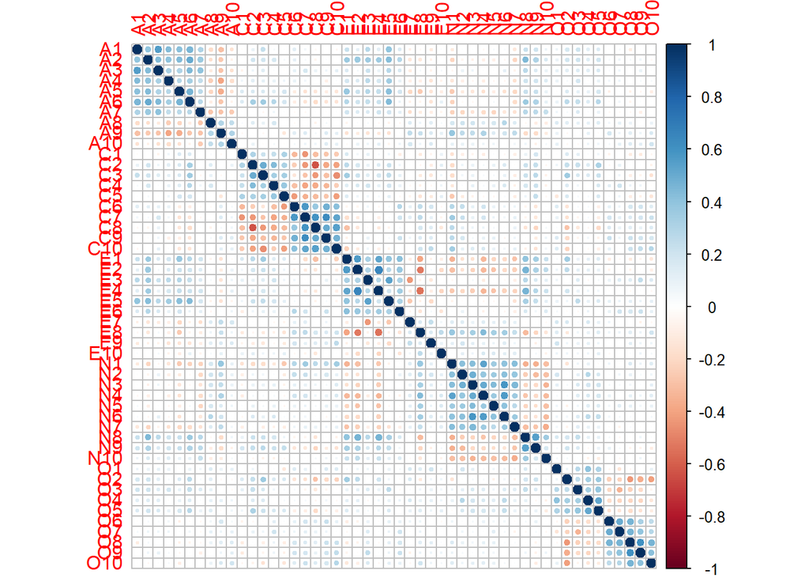

```r
#Visualization of correlations using circles
#corrplot parameters method = c("circle", "square", "ellipse", "number", "shade",
#"color", "pie")
#type = c("full", "lower", "upper"),
corrplot::corrplot(raqMatrix, method="circle")
```

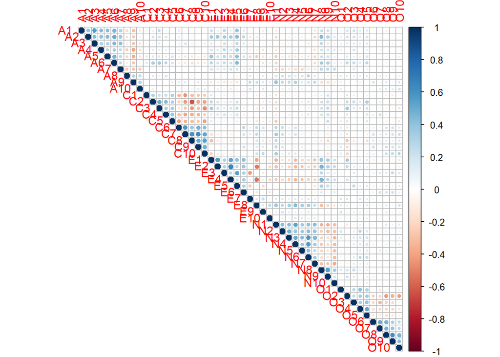

```r
corrplot::corrplot(raqMatrix, method="circle", type="upper")
```

[figure not shown]

```r
#Visualization using numbers
corrplot::corrplot(raqMatrix, method="number")
```

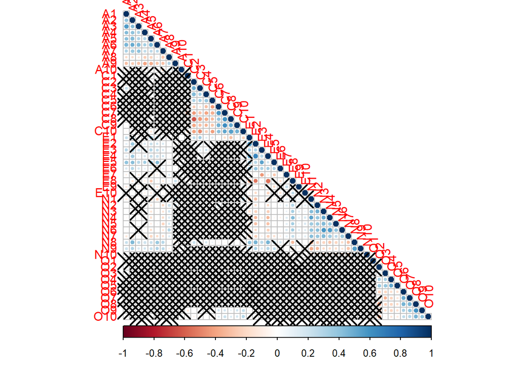

```r
#Visualization of significance levels at 0.05
res1 <- corrplot::cor.mtest(raqMatrix, conf.level = .95)
corrplot::corrplot(raqMatrix, p.mat = res1$p, type="lower", sig.level = .05)
```

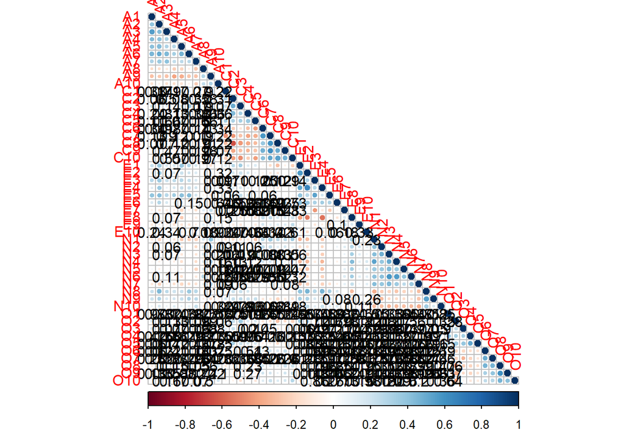

```r
#Showing p-value for non-significant results
corrplot(raqMatrix, p.mat = res1$p, type="lower",insig = "p-value")
```

Check if data is suitable - look at the relevant Statistics Bartlett’s test

```r
psych::cortest.bartlett(df2)
```

```
## R was not square, finding R from data
```

```
## $chisq
## [1] 8165.926
##
## $p.value
## [1] 0
##
## $df
## [1] 1225
```

```r
psych::cortest.bartlett(raqMatrix, n=nrow(df2))
```

```
## $chisq
## [1] 8165.926
##
## $p.value
## [1] 0
##
## $df
## [1] 1225
```

```r
#KMO (execute one of these):
REdaS::KMOS(df2)
```

```
##
## Kaiser-Meyer-Olkin Statistics
##
## Call: REdaS::KMOS(x = df2)
##
## Measures of Sampling Adequacy (MSA):
##        A1        A2        A3        A4        A5        A6        A7        A8
## 0.8487839 0.9183568 0.8064135 0.8116445 0.8911614 0.9017968 0.8178229 0.7311803
##        A9       A10        C1        C2        C3        C4        C5        C6
## 0.8675066 0.6936881 0.8391683 0.8631747 0.8960137 0.8459482 0.8495961 0.8585412
##        C7        C8        C9       C10        E1        E2        E3        E4
## 0.8529108 0.8723821 0.8714616 0.8652968 0.9095969 0.8786755 0.7560009 0.8869515
##        E5        E6        E7        E8        E9       E10        N1        N2
## 0.8474610 0.7926199 0.6776795 0.8582095 0.7140460 0.6992951 0.9123397 0.8890189
##        N3        N4        N5        N6        N7        N8        N9       N10
## 0.8766112 0.8868449 0.9029810 0.8415463 0.9069240 0.8754265 0.8700997 0.8433707
##        O1        O2        O3        O4        O5        O6        O7        O8
## 0.7459210 0.8197409 0.7985956 0.7874429 0.8682003 0.7844163 0.7799248 0.7989288
##        O9       O10
## 0.7927353 0.7879853
##
## KMO-Criterion: 0.8488853
```

```r
psych::KMO(df2)
```

```
## Kaiser-Meyer-Olkin factor adequacy
## Call: psych::KMO(r = df2)
## Overall MSA =  0.85
## MSA for each item =
##   A1   A2   A3   A4   A5   A6   A7   A8   A9  A10   C1   C2   C3   C4   C5   C6
## 0.85 0.92 0.81 0.81 0.89 0.90 0.82 0.73 0.87 0.69 0.84 0.86 0.90 0.85 0.85 0.86
##   C7   C8   C9  C10   E1   E2   E3   E4   E5   E6   E7   E8   E9  E10   N1   N2
## 0.85 0.87 0.87 0.87 0.91 0.88 0.76 0.89 0.85 0.79 0.68 0.86 0.71 0.70 0.91 0.89
##   N3   N4   N5   N6   N7   N8   N9  N10   O1   O2   O3   O4   O5   O6   O7   O8
## 0.88 0.89 0.90 0.84 0.91 0.88 0.87 0.84 0.75 0.82 0.80 0.79 0.87 0.78 0.78 0.80
##   O9  O10
## 0.79 0.79
```

According to the analysis we can observe that most of the values are above , .8. Indicates the proportion of variance in these variables caused by an underlying factor. Moreover according to the bartlett, it is evidant that the p value is <0.05.

checking the determinent

```r
###Determinant
#Determinant (execute one of these):
det(raqMatrix)
```

```
## [1] 1.752652e-10
```

```r
det(cor(df2))
```

```
## [1] 1.752652e-10
```

perform the dimension reduction

```r
#pcModel<-principal(dataframe/R-matrix, nfactors = number of factors, rotate = "method of rotation", scores = TRUE)

#On raw data using principal components analysis
#For PCA we know how many factors if is possible to find
#principal will work out our loadings of each variable onto each component, the proportion each component explained and the cumulative proportion of variance explained
pc1 <-  principal(df2, nfactors = 50, rotate = "none")
pc1 <-  principal(df2, nfactors = length(df2), rotate = "none")
pc1#output all details of the PCA
```

```
## Principal Components Analysis
## Call: principal(r = df2, nfactors = length(df2), rotate = "none")
## Standardized loadings (pattern matrix) based upon correlation matrix
##       PC1   PC2   PC3   PC4   PC5   PC6   PC7   PC8   PC9  PC10  PC11  PC12
## A1   0.40  0.12  0.46 -0.18 -0.35  0.00  0.17 -0.09 -0.02 -0.04 -0.09  0.15
## A2   0.54  0.22  0.47 -0.06 -0.08  0.03  0.09  0.05 -0.02 -0.02  0.11  0.01
## A3   0.28  0.17  0.51 -0.17 -0.35  0.10  0.16  0.08 -0.06  0.04  0.13  0.01
## A4   0.39  0.20  0.32 -0.06 -0.33  0.05  0.04  0.14 -0.08 -0.06 -0.30  0.24
## A5   0.56  0.09  0.22 -0.06 -0.25 -0.15 -0.02 -0.12 -0.15  0.27 -0.03  0.02
## A6   0.55 -0.08  0.43  0.02 -0.23  0.16  0.06 -0.05  0.02  0.06 -0.05  0.13
## A7   0.40  0.25  0.15 -0.21 -0.27  0.17 -0.07  0.33 -0.09 -0.07  0.19 -0.32
## A8  -0.20 -0.30  0.15  0.19  0.42  0.00 -0.09  0.08  0.19  0.18 -0.04  0.15
## A9  -0.46 -0.18  0.08  0.18  0.46  0.01 -0.01 -0.06  0.22 -0.16 -0.02 -0.18
## A10 -0.16 -0.01  0.11  0.20  0.51  0.08 -0.15 -0.13  0.04  0.19 -0.19  0.25
## C1   0.31 -0.34 -0.11  0.21 -0.02  0.12 -0.22 -0.06  0.06  0.18 -0.04  0.12
## C2   0.42 -0.51  0.21  0.35  0.08  0.06 -0.01 -0.06 -0.15 -0.25 -0.08  0.02
## C3   0.45 -0.41  0.22  0.22  0.06 -0.10  0.27 -0.18  0.11 -0.18 -0.08  0.05
## C4   0.33 -0.35  0.18  0.48  0.03  0.05 -0.02  0.23  0.00  0.11  0.13  0.04
## C5   0.38 -0.36 -0.09  0.30 -0.10  0.06  0.07 -0.05  0.14  0.36  0.04 -0.19
## C6  -0.34  0.42  0.40 -0.21  0.11 -0.05  0.19 -0.20 -0.02 -0.28  0.00  0.11
## C7  -0.45  0.52  0.36 -0.25  0.07  0.00  0.22 -0.09  0.19  0.03 -0.08 -0.05
## C8  -0.46  0.54  0.13 -0.26 -0.05 -0.02  0.03  0.12  0.15  0.34 -0.02  0.03
## C9  -0.37  0.51  0.30 -0.17  0.22  0.02  0.05 -0.18  0.19  0.19  0.03 -0.18
## C10 -0.45  0.47  0.27 -0.20  0.04  0.13 -0.21  0.18  0.06  0.10  0.14  0.18
## E1   0.67  0.08  0.14 -0.01  0.31 -0.23  0.07 -0.17 -0.03 -0.06  0.12 -0.02
## E2   0.58  0.18  0.09 -0.02  0.53 -0.21  0.02  0.17 -0.03  0.00  0.09  0.03
## E3   0.35  0.25  0.42  0.22 -0.01 -0.27 -0.42 -0.11  0.21  0.09  0.13  0.07
## E4   0.56  0.25  0.06  0.00  0.44 -0.25  0.00  0.22 -0.02 -0.03  0.00  0.00
## E5   0.45  0.16  0.49  0.11 -0.11 -0.17 -0.20 -0.19  0.21 -0.01 -0.15 -0.07
## E6   0.21  0.33  0.36  0.12  0.29 -0.36  0.16 -0.18 -0.20 -0.08  0.13 -0.14
## E7  -0.23 -0.20  0.04 -0.11  0.35  0.38  0.48  0.07 -0.12 -0.07 -0.21  0.07
## E8  -0.53 -0.16  0.32  0.00 -0.25  0.32 -0.05 -0.25  0.06 -0.06 -0.01  0.01
## E9  -0.26 -0.01  0.13 -0.09  0.34  0.29  0.02  0.11 -0.32  0.12  0.42  0.29
## E10 -0.09 -0.24  0.14  0.09 -0.12  0.41 -0.09 -0.38  0.16 -0.08  0.47 -0.12
## N1  -0.64 -0.09  0.34 -0.04  0.00 -0.25 -0.05  0.09  0.16 -0.10 -0.04  0.05
## N2  -0.40 -0.27  0.48 -0.02  0.06 -0.22  0.06 -0.10 -0.20  0.07  0.05 -0.05
## N3  -0.39 -0.37  0.48  0.04 -0.07 -0.21 -0.03  0.22  0.02 -0.01  0.06  0.07
## N4  -0.48 -0.34  0.43  0.04 -0.12 -0.02  0.08  0.08  0.17 -0.11  0.05  0.02
## N5  -0.36 -0.30  0.37  0.14 -0.14 -0.04  0.03 -0.08 -0.03  0.14 -0.03  0.19
## N6  -0.34 -0.45  0.47  0.06 -0.08 -0.09  0.09  0.28  0.04  0.00  0.11  0.05
```

[output cut: 242 more lines]

```
## Cumulative Proportion 0.91 0.91 0.92 0.93 0.94 0.94 0.95 0.96 0.96 0.97 0.97
##                       PC45 PC46 PC47 PC48 PC49 PC50
## SS loadings           0.26 0.25 0.24 0.23  0.2 0.19
## Proportion Var        0.01 0.00 0.00 0.00  0.0 0.00
## Cumulative Var        0.98 0.98 0.99 0.99  1.0 1.00
## Proportion Explained  0.01 0.00 0.00 0.00  0.0 0.00
## Cumulative Proportion 0.98 0.98 0.99 0.99  1.0 1.00
##
## Mean item complexity =  9.4
## Test of the hypothesis that 50 components are sufficient.
##
## The root mean square of the residuals (RMSR) is  0
##  with the empirical chi square  0  with prob <  NA
##
## Fit based upon off diagonal values = 1
```

step 4 : decide which components to retain here

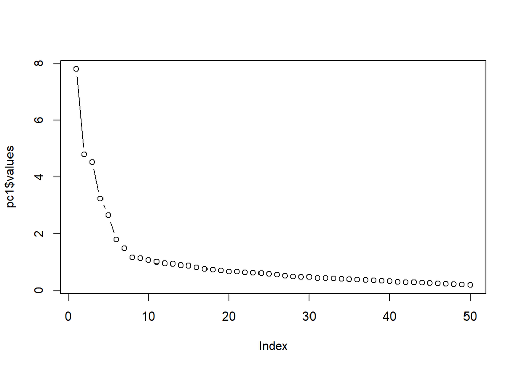

```r
#Create the scree plot
plot(pc1$values, type = "b")
```

```r
#Print the variance explained by each component
pc1$Vaccounted
```

```
##                             PC1        PC2        PC3        PC4        PC5
## SS loadings           7.7932058 4.77614727 4.52413779 3.23148433 2.65339456
## Proportion Var        0.1558641 0.09552295 0.09048276 0.06462969 0.05306789
## Cumulative Var        0.1558641 0.25138706 0.34186982 0.40649950 0.45956739
## Proportion Explained  0.1558641 0.09552295 0.09048276 0.06462969 0.05306789
## Cumulative Proportion 0.1558641 0.25138706 0.34186982 0.40649950 0.45956739
##                              PC6        PC7        PC8        PC9      PC10
## SS loadings           1.78485733 1.47541746 1.15389763 1.12815216 1.0643301
## Proportion Var        0.03569715 0.02950835 0.02307795 0.02256304 0.0212866
## Cumulative Var        0.49526454 0.52477289 0.54785084 0.57041389 0.5917005
## Proportion Explained  0.03569715 0.02950835 0.02307795 0.02256304 0.0212866
## Cumulative Proportion 0.49526454 0.52477289 0.54785084 0.57041389 0.5917005
##                             PC11       PC12       PC13       PC14       PC15
## SS loadings           1.00694161 0.95752849 0.93526895 0.89053785 0.86681836
## Proportion Var        0.02013883 0.01915057 0.01870538 0.01781076 0.01733637
## Cumulative Var        0.61183932 0.63098989 0.64969527 0.66750603 0.68484239
## Proportion Explained  0.02013883 0.01915057 0.01870538 0.01781076 0.01733637
## Cumulative Proportion 0.61183932 0.63098989 0.64969527 0.66750603 0.68484239
##                             PC16       PC17       PC18       PC19       PC20
## SS loadings           0.82102113 0.76092229 0.72976266 0.70623209 0.67223844
## Proportion Var        0.01642042 0.01521845 0.01459525 0.01412464 0.01344477
## Cumulative Var        0.70126282 0.71648126 0.73107651 0.74520116 0.75864592
## Proportion Explained  0.01642042 0.01521845 0.01459525 0.01412464 0.01344477
## Cumulative Proportion 0.70126282 0.71648126 0.73107651 0.74520116 0.75864592
##                             PC21       PC22       PC23       PC24       PC25
## SS loadings           0.66551757 0.64202845 0.63299242 0.61446532 0.59080769
## Proportion Var        0.01331035 0.01284057 0.01265985 0.01228931 0.01181615
## Cumulative Var        0.77195628 0.78479685 0.79745669 0.80974600 0.82156215
## Proportion Explained  0.01331035 0.01284057 0.01265985 0.01228931 0.01181615
## Cumulative Proportion 0.77195628 0.78479685 0.79745669 0.80974600 0.82156215
##                            PC26      PC27        PC28        PC29        PC30
## SS loadings           0.5564202 0.5124149 0.498088440 0.485078216 0.472153721
## Proportion Var        0.0111284 0.0102483 0.009961769 0.009701564 0.009443074
## Cumulative Var        0.8326906 0.8429389 0.852900624 0.862602188 0.872045262
## Proportion Explained  0.0111284 0.0102483 0.009961769 0.009701564 0.009443074
## Cumulative Proportion 0.8326906 0.8429389 0.852900624 0.862602188 0.872045262
##                              PC31        PC32        PC33        PC34
## SS loadings           0.434708659 0.432000731 0.418814420 0.410124571
## Proportion Var        0.008694173 0.008640015 0.008376288 0.008202491
## Cumulative Var        0.880739436 0.889379450 0.897755739 0.905958230
```

[output cut: 11 more lines]

```
## Cumulative Var        0.942776932 0.949457973 0.955642997 0.961435254
## Proportion Explained  0.006835922 0.006681041 0.006185024 0.005792257
## Cumulative Proportion 0.942776932 0.949457973 0.955642997 0.961435254
##                              PC43        PC44       PC45        PC46
## SS loadings           0.285195036 0.270458567 0.26313451 0.248335691
## Proportion Var        0.005703901 0.005409171 0.00526269 0.004966714
## Cumulative Var        0.967139155 0.972548326 0.97781102 0.982777730
## Proportion Explained  0.005703901 0.005409171 0.00526269 0.004966714
## Cumulative Proportion 0.967139155 0.972548326 0.97781102 0.982777730
##                              PC47        PC48        PC49        PC50
## SS loadings           0.241041171 0.225697470 0.202667786 0.191707079
## Proportion Var        0.004820823 0.004513949 0.004053356 0.003834142
## Cumulative Var        0.987598553 0.992112503 0.996165858 1.000000000
## Proportion Explained  0.004820823 0.004513949 0.004053356 0.003834142
## Cumulative Proportion 0.987598553 0.992112503 0.996165858 1.000000000
```

```r
#Print the Eigenvalues
View(pc1$values)
```

#Another way to look at eigen values plus variance explained (need to use princomp function of PCA to get right class for use with factoextra functions)

```r
pcf=princomp(df2)
factoextra::get_eigenvalue(pcf)
```

```
##        eigenvalue variance.percent cumulative.variance.percent
## Dim.1  10.1572925       15.7490957                    15.74910
## Dim.2   6.6098975       10.2487852                    25.99788
## Dim.3   5.5047093        8.5351676                    34.53305
## Dim.4   4.6385814        7.1922181                    41.72527
## Dim.5   3.2983284        5.1141275                    46.83939
## Dim.6   2.3452657        3.6363838                    50.47578
## Dim.7   1.8872383        2.9262027                    53.40198
## Dim.8   1.6174604        2.5079063                    55.90989
## Dim.9   1.4425127        2.2366463                    58.14653
## Dim.10  1.3457308        2.0865839                    60.23312
## Dim.11  1.2688667        1.9674046                    62.20052
## Dim.12  1.2396429        1.9220924                    64.12261
## Dim.13  1.1914303        1.8473377                    65.96995
## Dim.14  1.1532928        1.7882047                    67.75816
## Dim.15  1.0615480        1.6459525                    69.40411
## Dim.16  1.0072416        1.5617494                    70.96586
## Dim.17  0.9679638        1.5008483                    72.46671
## Dim.18  0.9328101        1.4463418                    73.91305
## Dim.19  0.9122830        1.4145140                    75.32756
## Dim.20  0.8921574        1.3833088                    76.71087
## Dim.21  0.8036791        1.2461213                    77.95699
## Dim.22  0.7929662        1.2295108                    79.18650
## Dim.23  0.7866947        1.2197867                    80.40629
## Dim.24  0.7807950        1.2106391                    81.61693
## Dim.25  0.7220529        1.1195582                    82.73649
## Dim.26  0.7070277        1.0962613                    83.83275
## Dim.27  0.6650578        1.0311861                    84.86393
## Dim.28  0.6364706        0.9868611                    85.85080
## Dim.29  0.6043747        0.9370957                    86.78789
## Dim.30  0.5822130        0.9027334                    87.69062
## Dim.31  0.5722569        0.8872963                    88.57792
## Dim.32  0.5610010        0.8698438                    89.44776
## Dim.33  0.5388279        0.8354640                    90.28323
## Dim.34  0.5124094        0.7945015                    91.07773
## Dim.35  0.4942666        0.7663708                    91.84410
## Dim.36  0.4734788        0.7341388                    92.57824
## Dim.37  0.4412413        0.6841538                    93.26239
## Dim.38  0.4328903        0.6712056                    93.93360
## Dim.39  0.4098469        0.6354762                    94.56908
## Dim.40  0.3900942        0.6048493                    95.17392
## Dim.41  0.3799173        0.5890698                    95.76299
## Dim.42  0.3558681        0.5517810                    96.31478
## Dim.43  0.3458410        0.5362337                    96.85101
## Dim.44  0.3386538        0.5250899                    97.37610
## Dim.45  0.3154653        0.4891356                    97.86523
## Dim.46  0.3118223        0.4834870                    98.34872
## Dim.47  0.2953444        0.4579377                    98.80666
## Dim.48  0.2853410        0.4424273                    99.24909
## Dim.49  0.2514171        0.3898275                    99.63891
## Dim.50  0.2328802        0.3610856                   100.00000
```

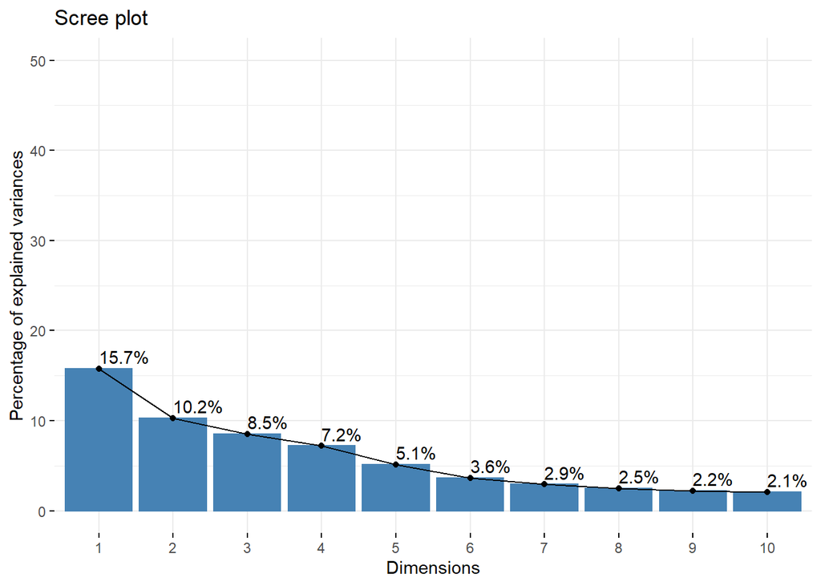

```r
factoextra::fviz_eig(pcf, addlabels = TRUE, ylim = c(0, 50))#Visualize the Eigenvalues
```

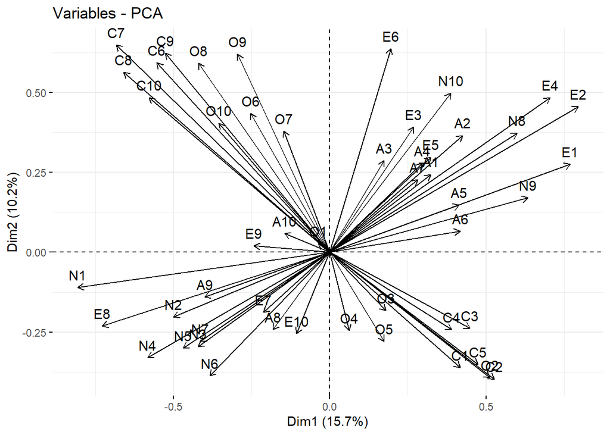

```r
factoextra::fviz_pca_var(pcf, col.var = "black")
```

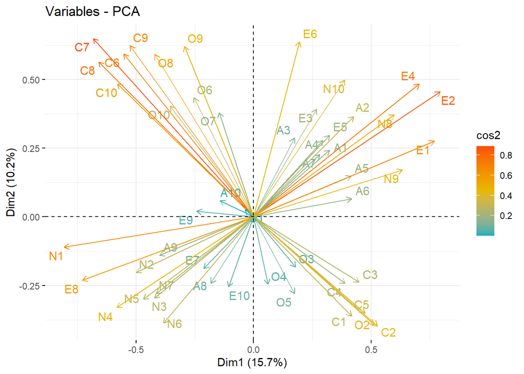

```r
factoextra::fviz_pca_var(pcf, col.var = "cos2",
             gradient.cols = c("#00AFBB", "#E7B800", "#FC4E07"),
             repel = TRUE # Avoid text overlapping
             )
```